# pefloxacin typhi analysis and figures

Philip Ashton

2023-02-23

# Libraries

```r
library(tidyverse)
library(patchwork)
library(kableExtra)
```

```r
library(broom)
library(sjPlot)
library(glue)
source('pefloxacin_typhi_functions.R')
```

# Read in data

```r
the_date <- '2023.02.22'
qech_pef_by_month_handle <- glue('data/{the_date}.qech_pef_results_per_month.csv')
sequencing_confirmed_typhi_opp_handle <- glue('data/{the_date}.sequencing_confirmed_typhi_opp.csv')
sequencing_confirmed_typhi_all_handle <- glue('data/{the_date}.sequencing_confirmed_typhi_all.csv')
cases_bc_qrdr_prescrip_microconf_handle <- glue('data/{the_date}.pef_typhi.cases_bc_qrdr_prescrip_microconf.csv')
strataa_tyvac_qrdr_typhi_handle <- glue('data/{the_date}.strataa_tyvac_qrdr_typhi.one_per_patient.csv')
tree_summaries_handle <- glue('data/{the_date}.tree_summaries.csv')
all_strataa_prescriptions_handle <- glue('data/{the_date}.all_strataa_prescriptions.csv')
```

Data has been pulled in from various sources and cleaned using `pefloxacin_typhi_data_cleaning.Rmd`. The clean data has been saved as `data/cases_bc_qrdr_prescrip_microconf_handle`.

```r
sequencing_confirmed_typhi_opp <- read_csv(sequencing_confirmed_typhi_opp_handle)
sequencing_confirmed_typhi_all <- read_csv(sequencing_confirmed_typhi_all_handle)
entire_recruitment_period <- read_csv(cases_bc_qrdr_prescrip_microconf_handle)
```

# STRATAA/TyVAC data summary

The number of sequencing confirmed typhoid cases and number of qrdr (sequencing confirmed), number of prescriptions of cipro, number of blood cultures, and number of microbiologically confirmed typhoid.

```r
typhoid_n <- sum(entire_recruitment_period$total_seq_typhoid_n)
typhi_n <- sum(entire_recruitment_period$total_seq_typhi_n)
prescrip_n <- sum(entire_recruitment_period$total_prescrip_n)
qrdr_n <- sum(entire_recruitment_period$total_qrdr_n)
bc_n <- sum(entire_recruitment_period$total_bc_n)
micro_conf_opp_n <- sum(entire_recruitment_period$micro_confirmed_opp_n)
micro_conf_all_n <- sum(entire_recruitment_period$micro_confirmed_all_n)
```

In total, over the entire study period there were:

- 239 cases of microbiologically confirmed typhoid (one per patient).
- 242 isolates S. Typhi.
- 193 cases of sequencing confirmed typhoid
- 196 cases of sequencing confirmed typhi (multiple isolates per patient in some cases)
- 807 prescriptions of cipro
- 10 QRDR typhoid (i.e. resistant)
- 11295 blood cultures

```r
new_ones_opp <- sequencing_confirmed_typhi_opp %>% filter(`paper sequences reported in` == 'This paper')
new_ones_all <- sequencing_confirmed_typhi_all %>% filter(`paper sequences reported in` == 'This paper')
```

In terms of new sequences (not in Dyson et al., 2023), there are:

- 55 total new sequences
- from 52 total new patients

# Investigating associations

After discussion with Marc, want to do one model with all the data from the entire study period. It doesn’t matter about the difference in recruitment criteria between strataa and tyvac because the important thing is the number of qrdr typhi per typhoid case, and the method of detecting those was consistent.

```r
m1 <- glm(cbind(total_qrdr_n, total_seq_typhoid_n-total_qrdr_n) ~ lag(total_prescrip_n),
         data = entire_recruitment_period,
         family = "binomial")

#summary(m1)
#m1_summary <- broom.mixed::tidy(m1, exponentiate = TRUE, conf.int = TRUE)
#m1_summary  %>% kbl() %>% kable_styling()

tab_model(m1, dv.labels = c('Proportion of S. Typhi that have a QRDR mutant ~ Number of ciprofloxacin prescriptions'))
```

|  | Proportion of S. Typhi that have a QRDR mutant ~ Number of ciprofloxacin prescriptions |  |  |
| --- | --- | --- | --- |
| Predictors | Odds Ratios | CI | p |
| (Intercept) | 0.01 | 0.00 – 0.04 | **<0.001** |
| total prescrip n | 1.04 | 1.02 – 1.06 | **<0.001** |
| Observations | 34 |  |  |

Checking for association between proportion of QRDR mutants and teh total number of blood cultures.

```r
m1 <- glm(cbind(total_qrdr_n, total_seq_typhoid_n-total_qrdr_n) ~ total_bc_n,
         data = entire_recruitment_period,
         family = "binomial")

summary(m1)
```

```
##
## Call:
## glm(formula = cbind(total_qrdr_n, total_seq_typhoid_n - total_qrdr_n) ~
##     total_bc_n, family = "binomial", data = entire_recruitment_period)
##
## Deviance Residuals:
##     Min       1Q   Median       3Q      Max
## -1.5305  -0.7097  -0.4449  -0.2414   2.8355
##
## Coefficients:
##              Estimate Std. Error z value Pr(>|z|)
## (Intercept) -3.669030   0.758406  -4.838 1.31e-06 ***
## total_bc_n   0.001778   0.001461   1.217    0.224
## ---
## Signif. codes:  0 '***' 0.001 '**' 0.01 '*' 0.05 '.' 0.1 ' ' 1
##
## (Dispersion parameter for binomial family taken to be 1)
##
##     Null deviance: 34.999  on 34  degrees of freedom
## Residual deviance: 33.484  on 33  degrees of freedom
## AIC: 49.306
##
## Number of Fisher Scoring iterations: 5
```

# Graphs

## Figure 1

This is a figure of the number of S. Typhi at QECH that were cipro sensitive and DCS.

```r
qech_pef_by_month <- read_csv(qech_pef_by_month_handle)
```

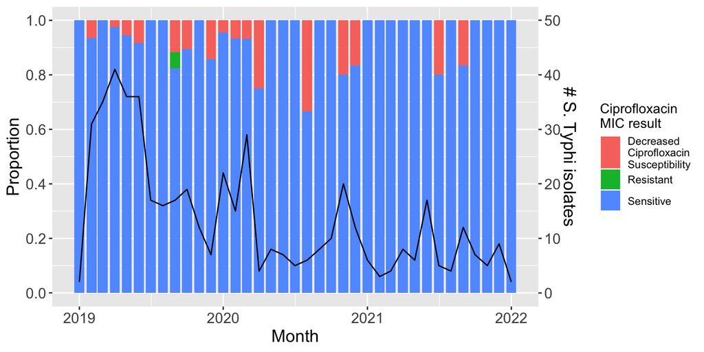

```r
qech_pef_by_month_for_plotting <- qech_pef_by_month
df <- qech_pef_by_month_for_plotting %>% group_by(Month) %>% summarise(n = sum(n)) %>% mutate(n = n / 50)

qech_n_graph <- ggplot(qech_pef_by_month_for_plotting, aes(x = Month, y = n, fill = `Cipro MIC res?`)) +
  geom_bar(stat = "identity") +
  ylab("Count") +
  theme(axis.text=element_text(size=12), axis.title=element_text(size=14)) +
  ggtitle('A)') +
  scale_fill_discrete(name = "Ciprofloxacin\nMIC result",  labels = c("Decreased\nCiprofloxacin\nSusceptibility", "Resistant", "Sensitive"))

qech_prop_graph <- ggplot() +
  geom_bar(qech_pef_by_month_for_plotting, mapping = aes(x = Month, y = n, fill = `Cipro MIC res?`), position = 'fill', stat = "identity") +
  geom_line(df, mapping = aes(x = Month, y = n)) +
  # secondary axis plot https://stackoverflow.com/questions/3099219/ggplot-with-2-y-axes-on-each-side-and-different-scales
  scale_y_continuous("Proportion", breaks = (seq(0,1, by = 0.2)), sec.axis = sec_axis(~ . * 50, name = "# S. Typhi isolates", breaks = seq(0, 50, by = 10))) +
  theme(axis.text=element_text(size=12), axis.title=element_text(size=14)) +
  scale_fill_discrete(name = "Ciprofloxacin\nMIC result", labels = c("Decreased\nCiprofloxacin\nSusceptibility", "Resistant", "Sensitive"))

qech_prop_graph
```

```r
#qech_n_graph / qech_prop_graph #+ plot_layout(heights = c(100, 100))
```

Test for trend in proportions

```r
qech_pef_by_month_w <- pivot_wider(qech_pef_by_month, names_from = `Cipro MIC res?`, values_from = n) %>% replace_na(list(DCS = 0, R= 0)) %>% mutate(n = S + DCS + R, e = DCS + R)

prop.trend.test(qech_pef_by_month_w$e, qech_pef_by_month_w$n)
```

```
##
##  Chi-squared Test for Trend in Proportions
##
## data:  qech_pef_by_month_w$e out of qech_pef_by_month_w$n ,
##  using scores: 1 2 3 4 5 6 7 8 9 10 11 12 13 14 15 16 17 18 19 20 21 22 23 24 25 26 27 28 29 30 31 32 33 34 35 36 37
## X-squared = 0.41932, df = 1, p-value = 0.5173
```

### Numbers for Figure 1

```r
total_qech_typhi_tested <- sum(qech_pef_by_month$n)
total_qech_typhi_dcs_or_r <- filter(qech_pef_by_month, `Cipro MIC res?` == 'DCS' | `Cipro MIC res?` == 'R' ) %>% pull(n) %>% sum
```

There were 503 total qech typhi tested, and 30 DCS or R.

## Figure 2

Read in the info about the qrdr samples.

```r
strataa_tyvac_qrdr_typhi <- read_csv(strataa_tyvac_qrdr_typhi_handle, col_types = cols(`Properly formatted date` = col_date(format = "%Y-%m-%d")))
strataa_tyvac_qrdr_typhi$Month <- as.Date(cut(strataa_tyvac_qrdr_typhi$`Properly formatted date`, breaks = "month"))
```

Graphs of the counts of typhi cases, qrdr cases, cipro prescriptions and blood cultures from the entire strataa/tyvac recruitment period.

```r
entire_period_tpqb_graph <- plot_typh_presc_qrdr_bc_n(entire_recruitment_period, strataa_tyvac_qrdr_typhi) # tpqb stands for typhoid, prescriptions, qrdr and blood cultures
```

[output not shown]

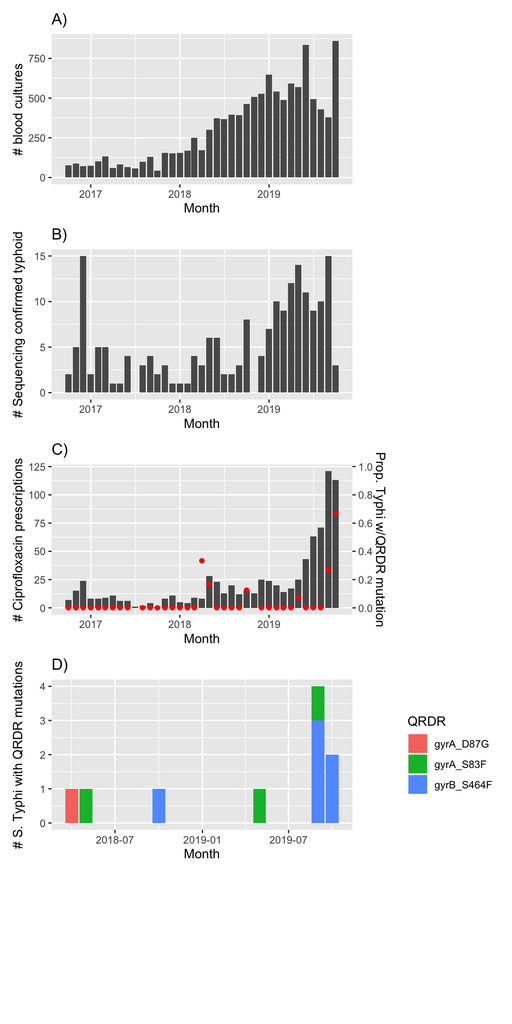

```r
entire_period_tpqb_graph
```

### Numbers for Figure 2

```r
qrdr_before_sept019 <- strataa_tyvac_qrdr_typhi %>% filter(`Properly formatted date` < '2019-09-01')
qrdr_sept_oct2019 <- strataa_tyvac_qrdr_typhi %>% filter(`Properly formatted date` >= '2019-09-01' & `Properly formatted date` <= '2019-10-31')

mutations_before_sept2019 <- qrdr_before_sept019 %>% group_by(QRDR) %>% summarise(n = n())
mutations_sept_oct2019 <- qrdr_sept_oct2019 %>% group_by(QRDR) %>% summarise(n = n())

#before_sept19 <- entire_recruitment_period %>% filter(`Month` < '2019-09-01')
#after_sept19 <- entire_recruitment_period %>% filter(`Month` >= '2019-09-01')

before_after_sept19 <- entire_recruitment_period %>% mutate(before_after_sept19 = ifelse(Month < '2019-09-01', 'before_sept19', 'after_sept19')) %>% group_by(before_after_sept19, ) %>% summarise(total_seq_typhoid_n = sum(total_seq_typhoid_n), total_qrdr_n = sum(total_qrdr_n)) %>% mutate(pct_qrdr = (total_qrdr_n / total_seq_typhoid_n) * 100)
before_after_sept19 %>% kbl() %>% kable_styling()
```

| before_after_sept19 | total_seq_typhoid_n | total_qrdr_n | pct_qrdr |
| --- | --- | --- | --- |
| after_sept19 | 18 | 6 | 33.333333 |
| before_sept19 | 175 | 4 | 2.285714 |

Get the Number of typhoid cases before/after Dec 2018

```r
entire_recruitment_period %>% mutate(bef_aft_dec18 = ifelse(Month <= "2018-12-01", 'before_dec18', 'after_dec18')) %>% group_by(bef_aft_dec18) %>% summarise(min_tyhpoid = min(total_seq_typhoid_n), max_tyhpoid = max(total_seq_typhoid_n), median_tyhpoid = median(total_seq_typhoid_n)) %>% kbl() %>% kable_styling()
```

| bef_aft_dec18 | min_tyhpoid | max_tyhpoid | median_tyhpoid |
| --- | --- | --- | --- |
| after_dec18 | 3 | 15 | 10 |
| before_dec18 | 0 | 15 | 3 |

Get the max, min and average number of prescriptions and qrdr cases before/after May 2019.

```r
entire_recruitment_period %>% mutate(bef_aft_may19 = ifelse(Month <= "2019-05-01", 'before_may19', 'after_may19')) %>% group_by(bef_aft_may19) %>% summarise(min_prescrip = min(total_prescrip_n), max_prescrip = max(total_prescrip_n), median_prescrip = median(total_prescrip_n), min_qrdr = min(total_qrdr_n), max_qrdr = max(total_qrdr_n), mean_qrdr = mean(total_qrdr_n)) %>% kbl() %>% kable_styling()
```

| bef_aft_may19 | min_prescrip | max_prescrip | median_prescrip | min_qrdr | max_qrdr | mean_qrdr |
| --- | --- | --- | --- | --- | --- | --- |
| after_may19 | 43 | 121 | 71 | 0 | 4 | 1.200 |
| before_may19 | 1 | 28 | 11 | 0 | 1 | 0.125 |

```r
x <- c(4, 6)
y <- c(171, 12)
prop.test(x, y, p = NULL, alternative = "two.sided")
```

```
##
##  2-sample test for equality of proportions with continuity correction
##
## data:  x out of y
## X-squared = 40.512, df = 1, p-value = 1.954e-10
## alternative hypothesis: two.sided
## 95 percent confidence interval:
##  -0.8050009 -0.1482155
## sample estimates:
##     prop 1     prop 2
## 0.02339181 0.50000000
```

There were 4 QRDR Typhi isolated between 1st October 2016 and 31th August 2019.

There were 6 QRDR Typhi isolated between 1st September 2019 and 31st October 2019.

Before Sept2019

| QRDR | n |
| --- | --- |
| gyrA_D87G | 1 |
| gyrA_S83F | 2 |
| gyrB_S464F | 1 |

Sept-Oct 2019

| QRDR | n |
| --- | --- |
| gyrA_S83F | 1 |
| gyrB_S464F | 5 |

# Pheno-geno comparison

```r
pheno_or_geno <- sequencing_confirmed_typhi_opp %>% filter((`Pefloxacin 5` == 'R' | `Pefloxacin 5` == 'I') | (`Cipro MIC res?` == 'DCS' | `Cipro MIC res?` == 'R') | !is.na(QRDR)) %>% select(c(`Request Number`, `Pefloxacin 5`, `Ciprofloxacin MIC`, `Cipro MIC res?`, QRDR, any_qrdr)) %>% replace_na(list(QRDR = 'None', any_qrdr = 'None'))

table(pheno_or_geno$any_qrdr, pheno_or_geno$`Cipro MIC res?`)
```

```
##
##        DCS S
##   None   1 4
##   QRDR   9 1
```

# Summaries of the numbers in each phylo

```r
all_tree_summaries <- read_csv(tree_summaries_handle)
context <- all_tree_summaries %>% filter(tree == 'malawian_and_context') %>% filter(Country != 'Malawi')

number_of_nonmalawian_context_genomes <- sum(context$n)
```

There were 1970 non-Malawian contextual genomes included in the analysis.

Table of the number of genomes included from each location in each tree.

| Country | study_summary | n | tree |
| --- | --- | --- | --- |
| Malawi | context | 112 | all_malawian |
| Malawi | this_study | 187 | all_malawian |
| Africa | context | 1 | malawi_and_zim |
| Malawi | context | 71 | malawi_and_zim |
| Malawi | this_study | 183 | malawi_and_zim |
| South Africa | context | 4 | malawi_and_zim |
| Zimbabwe | context | 27 | malawi_and_zim |
| Africa | context | 3 | malawian_and_context |
| Asia | context | 1051 | malawian_and_context |
| Central Africa | context | 20 | malawian_and_context |
| East Africa | context | 224 | malawian_and_context |
| Europe | context | 6 | malawian_and_context |
| Malawi | context | 112 | malawian_and_context |
| Malawi | this_study | 187 | malawian_and_context |
| North Africa | context | 25 | malawian_and_context |
| North America | context | 5 | malawian_and_context |
| Oceania | context | 335 | malawian_and_context |
| South America | context | 17 | malawian_and_context |
| Southern Africa | context | 74 | malawian_and_context |
| Unknown | context | 18 | malawian_and_context |
| West Africa | context | 192 | malawian_and_context |

# Supplmentary Figure 1 - Plot number of sequenced and unsequenced typhi cases

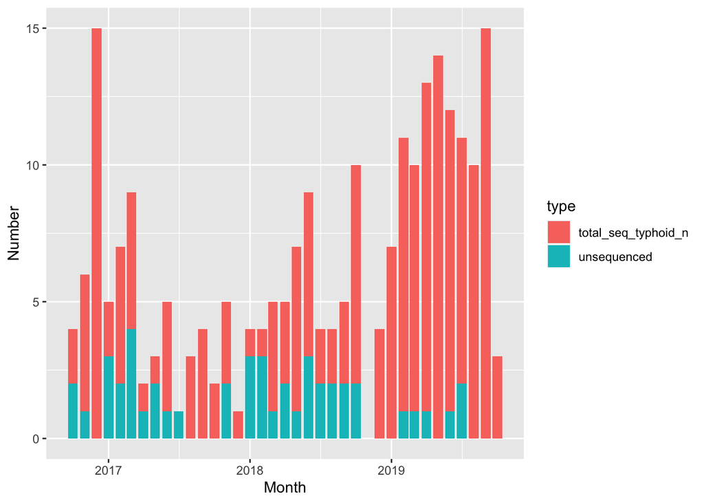

```r
seq_unseq_cases <- entire_recruitment_period %>% select(Month, total_seq_typhoid_n, micro_confirmed_opp_n) %>% mutate(unsequenced = micro_confirmed_opp_n - total_seq_typhoid_n)
seq_unseq_cases_l <- seq_unseq_cases %>% select(Month, total_seq_typhoid_n, unsequenced) %>% pivot_longer(!Month, names_to = "type", values_to = "Number")
ggplot(seq_unseq_cases_l, aes(x = Month, y = Number, fill = type)) +
  geom_bar(stat = "identity")
```

# Supplementary Figure 4 - numbers of strataa prescriptions of different drugs

```r
all_strataa_prescriptions_g <- read_csv(all_strataa_prescriptions_handle)
```

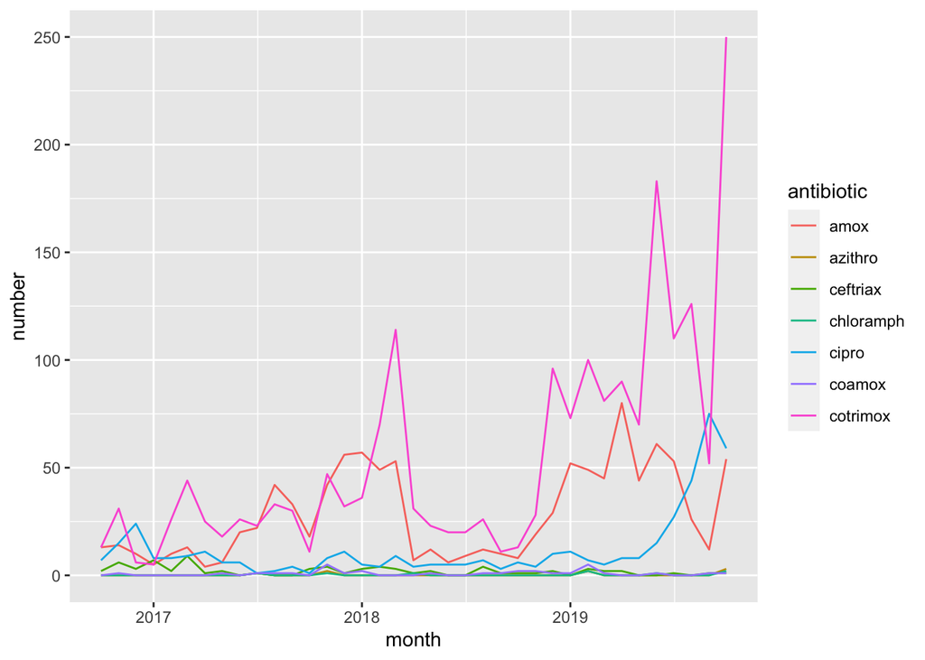

```r
ggplot(all_strataa_prescriptions_g, aes(x = month, y = number, colour = antibiotic)) + geom_line()
```